# Activity Monitoring

load required packages:

```r
required <- c('ggplot2','knitr')
lapply(required,require,character.only=TRUE)
```

```
## [[1]]
## [1] TRUE
##
## [[2]]
## [1] TRUE
```

Download and read data into R:

```r
fileurl <- 'http://d396qusza40orc.cloudfront.net/repdata%2Fdata%2Factivity.zip'
if(!file.exists('mon.zip')) {download.file(fileurl, destfile = 'mon.zip')}
downdate <- date()
data <- read.csv(unz('mon.zip','activity.csv'))
```

Data was downloaded from link above on Tue Aug 26 12:19:05 2014.

## Data Cleaning

```r
str(data) #look at data
```

```
## 'data.frame':    17568 obs. of  3 variables:
##  $ steps   : int  NA NA NA NA NA NA NA NA NA NA ...
##  $ date    : Factor w/ 61 levels "2012-10-01","2012-10-02",..: 1 1 1 1 1 1 1 1 1 1 ...
##  $ interval: int  0 5 10 15 20 25 30 35 40 45 ...
```

```r
data$date <- as.Date(as.character(data$date),format='%Y-%m-%d') #convert to Date format
```

## Data Analysis

### Part1

What is mean total number of steps taken per day?  
* Historgram for total number of steps per day  
* Mean and median of total number of steps per day

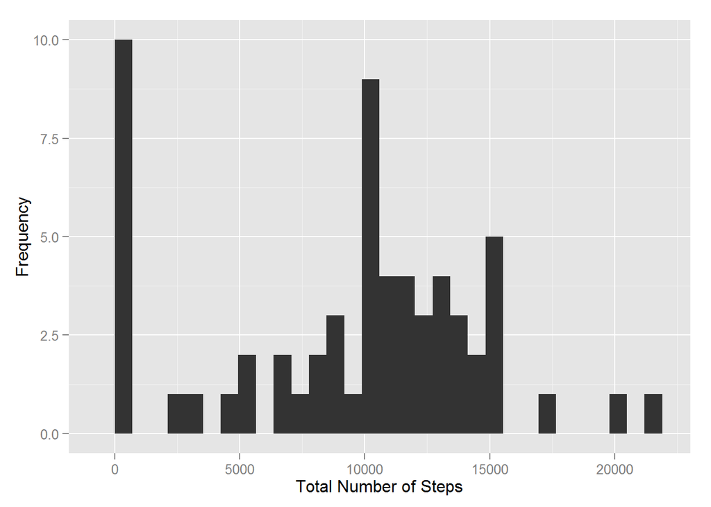

```r
tsum<- tapply(data$steps,data$date,sum,na.rm=T)
dfsum<-data.frame(tsum)
p1<- ggplot(data=dfsum,aes(x=tsum))
p1<- p1+geom_histogram()
p1<- p1+labs(x='Total Number of Steps',y='Frequency')
p1
```

```r
outmat <- matrix(nrow=length(unique(data$date)),ncol=2,dimnames = list(as.character(unique(data$date)),c('mean','median')))
mm <- sapply(list('mean','median'),function(x){ tmp<-tapply(data$steps, data$date, x,na.rm=T); outmat[,x]<<- tmp})
outmat #mean and median per day
```

[output not shown]

[output not shown]

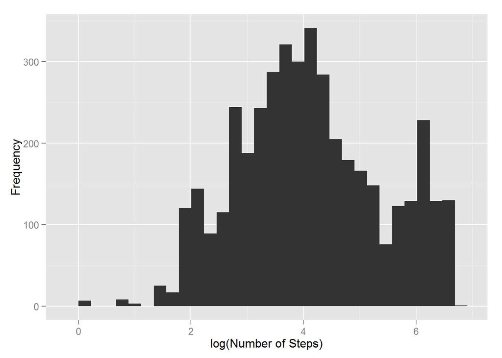

```r
p1<- ggplot(data=data[data$steps!=0,],aes(x=log(steps)))
p1<- p1+geom_histogram()
p1<- p1+labs(x='log(Number of Steps)',y='Frequency')
p1
```

```r
outmat <- matrix(nrow=length(unique(data$date)),ncol=2,dimnames = list(as.character(unique(data$date)),c('mean','median')))
mm <- sapply(list('mean','median'),function(x){ tmp<-tapply(data$steps, data$date, x,na.rm=T); outmat[,x]<<- tmp})
outmat
```

```
##               mean median
## 2012-10-01     NaN     NA
## 2012-10-02  0.4375      0
## 2012-10-03 39.4167      0
## 2012-10-04 42.0694      0
## 2012-10-05 46.1597      0
## 2012-10-06 53.5417      0
## 2012-10-07 38.2465      0
## 2012-10-08     NaN     NA
## 2012-10-09 44.4826      0
## 2012-10-10 34.3750      0
## 2012-10-11 35.7778      0
## 2012-10-12 60.3542      0
## 2012-10-13 43.1458      0
## 2012-10-14 52.4236      0
## 2012-10-15 35.2049      0
## 2012-10-16 52.3750      0
## 2012-10-17 46.7083      0
## 2012-10-18 34.9167      0
## 2012-10-19 41.0729      0
## 2012-10-20 36.0938      0
## 2012-10-21 30.6285      0
## 2012-10-22 46.7361      0
## 2012-10-23 30.9653      0
## 2012-10-24 29.0104      0
## 2012-10-25  8.6528      0
## 2012-10-26 23.5347      0
## 2012-10-27 35.1354      0
## 2012-10-28 39.7847      0
## 2012-10-29 17.4236      0
## 2012-10-30 34.0938      0
## 2012-10-31 53.5208      0
## 2012-11-01     NaN     NA
## 2012-11-02 36.8056      0
## 2012-11-03 36.7049      0
## 2012-11-04     NaN     NA
## 2012-11-05 36.2465      0
## 2012-11-06 28.9375      0
## 2012-11-07 44.7326      0
## 2012-11-08 11.1771      0
## 2012-11-09     NaN     NA
## 2012-11-10     NaN     NA
## 2012-11-11 43.7778      0
## 2012-11-12 37.3785      0
## 2012-11-13 25.4722      0
## 2012-11-14     NaN     NA
## 2012-11-15  0.1424      0
## 2012-11-16 18.8924      0
## 2012-11-17 49.7882      0
## 2012-11-18 52.4653      0
## 2012-11-19 30.6979      0
## 2012-11-20 15.5278      0
## 2012-11-21 44.3993      0
## 2012-11-22 70.9271      0
## 2012-11-23 73.5903      0
## 2012-11-24 50.2708      0
## 2012-11-25 41.0903      0
## 2012-11-26 38.7569      0
## 2012-11-27 47.3819      0
## 2012-11-28 35.3576      0
## 2012-11-29 24.4688      0
## 2012-11-30     NaN     NA
```

```r
mean(dfsum$tsum) #mean of total number of steps for the entire dataset
```

```
## [1] 9354
```

```r
median(dfsum$tsum) #median of total number of steps for the entire dataset
```

```
## [1] 10395
```